# Exam 3 CSCE 633 Machine Learning

## Exam 3 - CSCE 633 600 (Machine Learning)

## Name: Rohan Chaudhury

## UIN: 432001358

### Question: Clustering countries based on longitude and lattitude

In this exam we will focus on a clustering problem to group countries based on their geograph- ical location.

We will be considering the longitude and latitude of 240 countries, as provided in "data.csv" file on CANVAS. The rows of the file refer to the countries (i.e., samples) of the dataset. The columns denote the country name (column 1), as well as the longitude (column 2) and latitude (column 3) of each country.

```python
import matplotlib.pyplot as plt
import pandas as pd
import numpy as np
import matplotlib.pyplot as plt
from sklearn.cluster import KMeans
from sklearn import metrics
from scipy.spatial.distance import cdist
from sklearn.mixture import GaussianMixture
from matplotlib.colors import LogNorm
```

### (1) (3 points) Data visualization: Plot a 2-D scatter plot of the data. Provide explainations and insights regarding the resulting scatter plot.

```python
file_train="data.csv"
train_rows =pd.read_csv(file_train)
print (train_rows.head())
print (" ")
print("Total no. of rows in hw2_data.csv: %d \n"%(len(train_rows)))
print (" ")
print("Total no. of colums in hw2_data.csv: %d \n"%(train_rows.shape[1]))
```

```
          name  Longitude   Latitude
0        Aruba -69.982677  12.520880
1  Afghanistan  66.004734  33.835231
2       Angola  17.537368 -12.293361
3     Anguilla -63.064989  18.223959
4      Albania  20.049834  41.142450

Total no. of rows in hw2_data.csv: 241


Total no. of colums in hw2_data.csv: 3
```

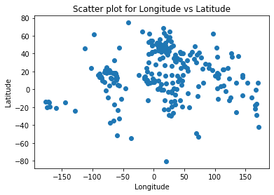

```python
plt.figure(1)
plt.scatter(x=train_rows.iloc[:,1],y=train_rows.iloc[:,2])
plt.xlabel(train_rows.columns[1])
plt.ylabel(train_rows.columns[2])
plt.title('Scatter plot for {} vs {}'.format (train_rows.columns[1],train_rows.columns[2]))
plt.show()
```

### Answer:

A 2-D scatter plot of the data is shown above. The x-axis denotes the Longitude of the countries and the y-axis denotes the Latitude of the countries. We are able to see that some clusters have formed in the plot and the plot somewhat resembles a World Map.

### (2) (5 points) K-Means Clustering: Apply K-Means clustering to group the samples of the dataset using K = 2, 3, 4, . . . , 10. Provide the color-coded scatter plots for each K, where each color in the scatter plot represents a cluster.

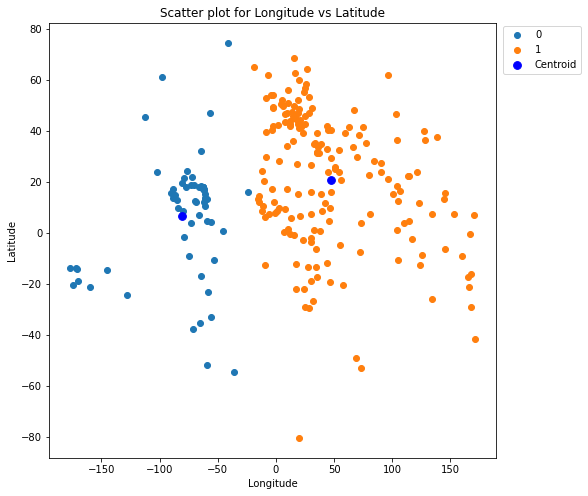

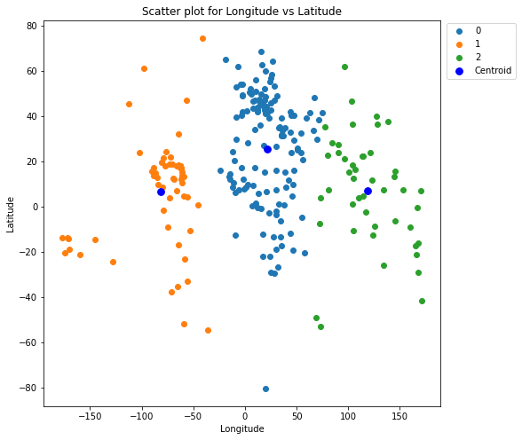

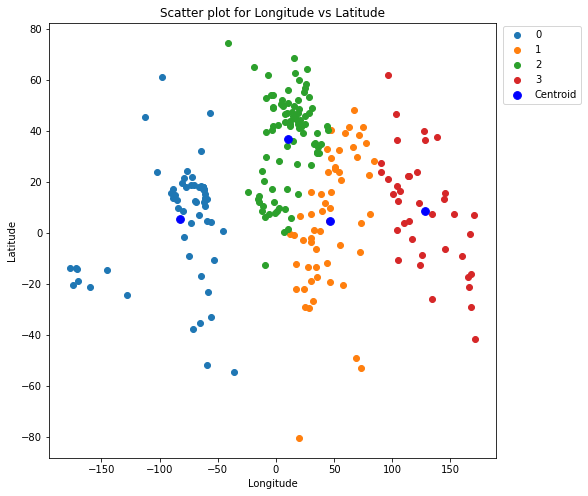

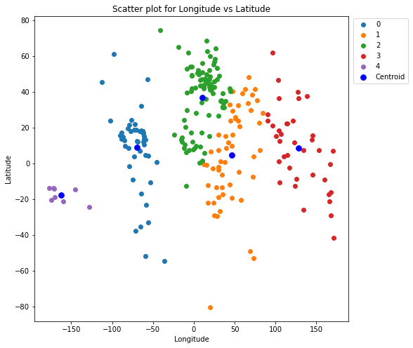

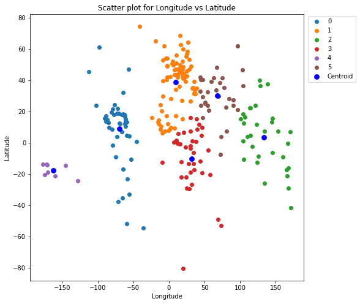

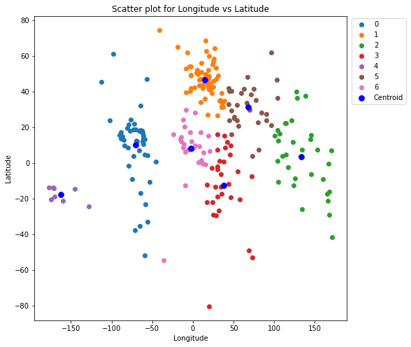

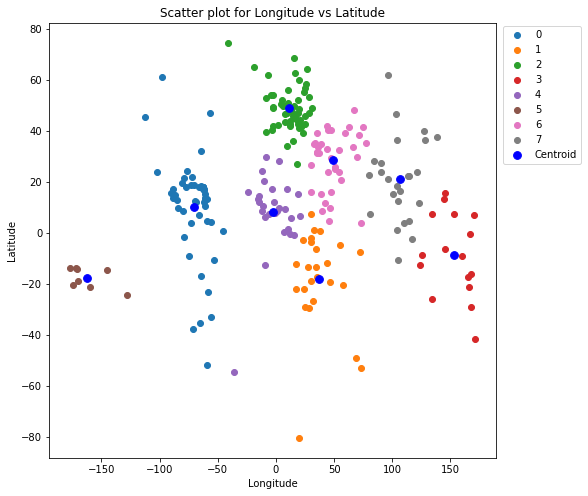

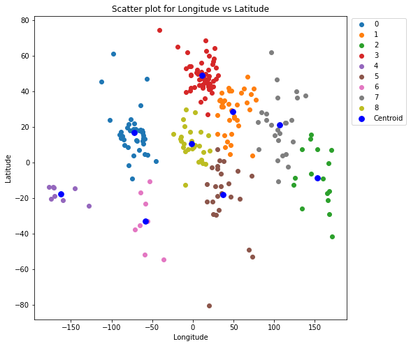

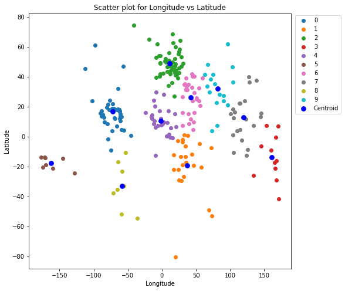

```python
feature_set=['Longitude','Latitude']
X_matrix=train_rows.loc[:,feature_set]



for i in range(2,11):
    kmeans = KMeans(n_clusters=i, random_state=0).fit(X_matrix)
    plt.figure(figsize=(8, 8))

    labels=set(kmeans.labels_)
    for k in labels:
        plt.scatter(X_matrix.iloc[kmeans.labels_ == k , 0] , X_matrix.iloc[kmeans.labels_ == k , 1] , label = k)
    plt.scatter(kmeans.cluster_centers_[:,0] , kmeans.cluster_centers_[:,1], s=60, color='b',label='Centroid')
    plt.xlabel(train_rows.columns[1])
    plt.ylabel(train_rows.columns[2])
    plt.title('Scatter plot for {} vs {}'.format (train_rows.columns[1],train_rows.columns[2]))
    plt.legend(bbox_to_anchor=(1.005,1.005), loc="upper left")
    plt.show()
```

### Answer:

K-Means clustering is applied to group the samples of the dataset using K = 2, 3, 4, . . . , 10. The color-coded scatter plots for each K is shown above, where each color in the scatter plot represents a cluster.

### (3) (2 points) Elbow method for K-Means Clustering: Based on the scatter plots from question (2) and using the elbow method, determine and discuss the number of clusters that makes most sense for the data.

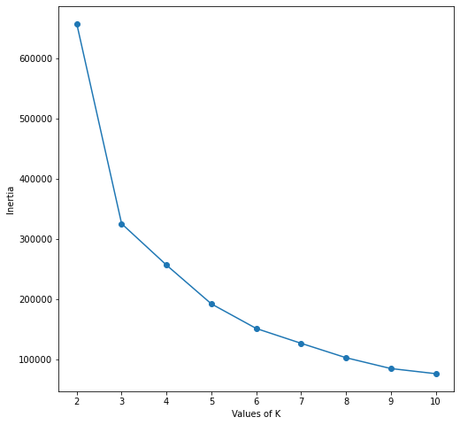

```python
inertias=[]

for i in range(2,11):
    kmeans = KMeans(n_clusters=i, random_state=0).fit(X_matrix)
    inertias.append(kmeans.inertia_)

plt.figure(figsize=(8, 8))
plt.plot(range(2,11), inertias, '-o')
plt.xlabel('Values of K')
plt.ylabel('Inertia');
```

### Answer:

The sum of squared distance is used in the elbow method to choose an ideal value of k based on the distance between the sample points and their assigned clusters center. We will choose a value of k where we see an inflection point and the sum of squared distance begins to flatten out. When we are visualizing this graph, it looks somewhat like an elbow. The plot above shows that k = 3 is probably a good choice for the number of clusters. Also, from the above scatter plots we can see k=3 is a good choice, but k=4 and k=5 also seems like a good choice for the dataset. Based on both the elbow method and the scatter plots we can say that k=3 is a reasonable choice for the dataset.

### (4) (5 points) Clustering with Gaussian Mixture Models: Apply a Gaussian mixture models using 5 Gaussians to group the samples of the dataset. Report the mean and covariance of each Gaussian and briefly discuss these results. How does this clustering result compare to the one obtained by the K-Means algorithm? Please also examine and discuss the log-likelihood of a sample belonging to each Gaussian for 1-2 samples.

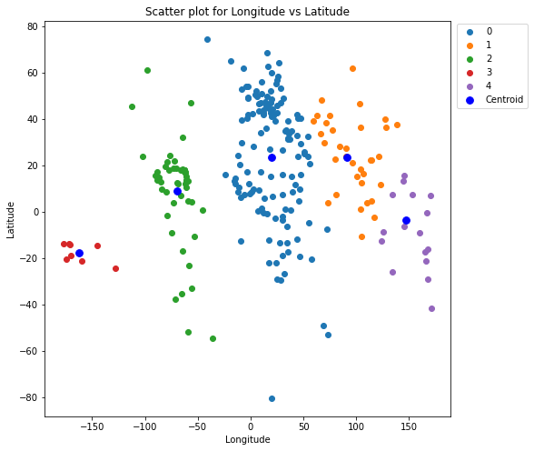

```python
gm = GaussianMixture(n_components=5, random_state=42).fit(X_matrix)
plt.figure(figsize=(8, 8))
gm_labels=gm.predict(X_matrix)
unique_gm_labels=set(gm_labels)
for k in unique_gm_labels:
    plt.scatter(X_matrix.iloc[gm_labels == k , 0] , X_matrix.iloc[gm_labels == k , 1] , label = k)
plt.scatter(gm.means_[:,0] , gm.means_[:,1], s=60, color='b',label='Centroid')
plt.xlabel(train_rows.columns[1])
plt.ylabel(train_rows.columns[2])
plt.title('Scatter plot for {} vs {}'.format (train_rows.columns[1],train_rows.columns[2]))
plt.legend(bbox_to_anchor=(1.005,1.005), loc="upper left")
plt.show()
```

```python
gm.covariances_
```

```
array([[[ 455.56378089, -184.6583895 ],
        [-184.6583895 ,  779.61855833]],

       [[ 825.54355304, -202.61323962],
        [-202.61323962,  293.63883194]],

       [[ 192.19834557, -146.38587303],
        [-146.38587303,  472.10039597]],

       [[ 259.01841824,  -33.00979178],
        [ -33.00979178,   14.57255797]],

       [[ 436.71361262, -234.89137398],
        [-234.89137398,  420.59870491]]])
```

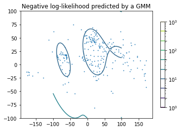

```python
x = np.linspace(-100.0, 100.0)
y = np.linspace(-100.0, 100.0)
X, Y = np.meshgrid(x, y)
XX = np.array([X.ravel(), Y.ravel()]).T
Z = -gm.score_samples(XX)
Z = Z.reshape(X.shape)

CS = plt.contour(
    X, Y, Z, norm=LogNorm(vmin=1.0, vmax=1000.0), levels=np.logspace(0, 3, 10)
)
CB = plt.colorbar(CS, shrink=0.8, extend="both")
plt.scatter(X_matrix.iloc[:, 0], X_matrix.iloc[:, 1], 0.8)

plt.title("Negative log-likelihood predicted by a GMM")
plt.axis("tight")
plt.show()
```